# My visual data story

JIE XU (444883280)

2025-05-15

## Introduction: Unveiling the Story Behind the Shifts

Based on an adjustment to the research direction, this project takes a deep dive into the operations of the store where I work part-time, conducting a systematic observation of shift schedules, managerial supervision, and employee overtime throughout the year 2025. The goal is to use data visualization to clearly reveal the key drivers behind overtime, gain insights into opportunities for improving work efficiency, examine the pressures faced by employees, and ultimately provide data-driven support for optimizing management strategies — telling a story dedicated to balance and improvement.

## Finding 1: The Weekly Rhythm of Overtime

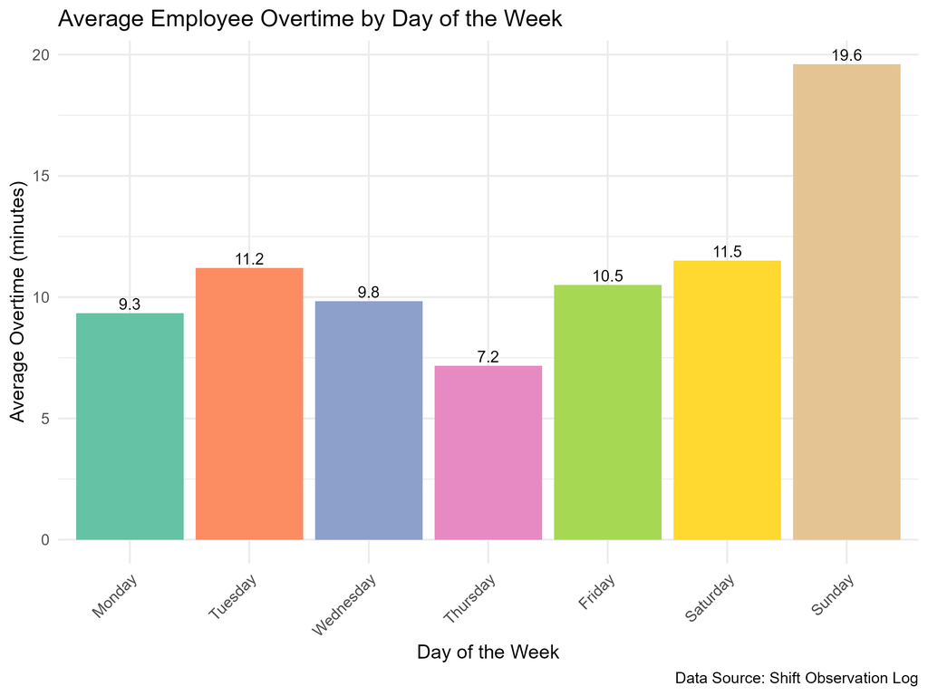

Bar chart depicting average employee overtime in minutes from Monday to Sunday. Sunday shows the highest bar (approx. 19.6 mins), while Thursday shows the lowest (approx. 7.2 mins).

The average overtime on Sundays is the longest, approaching 20 minutes—significantly higher than any other day. In contrast, Thursday has the shortest average overtime duration, at around 7 minutes.

These findings suggest that weekends, especially Sundays, may be the periods of highest work pressure, tightest staffing, or most concentrated tasks. In contrast, Thursdays appear to be relatively relaxed.

## Finding 2: The Manager’s Gaze - Does Presence Impact Overtime?

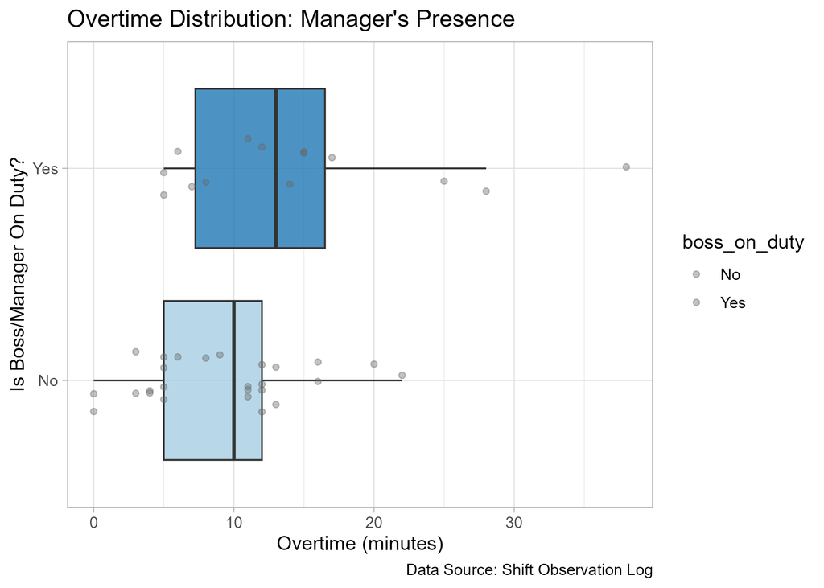

## Finding 3: Decoding Staffing in Core Shift Periods

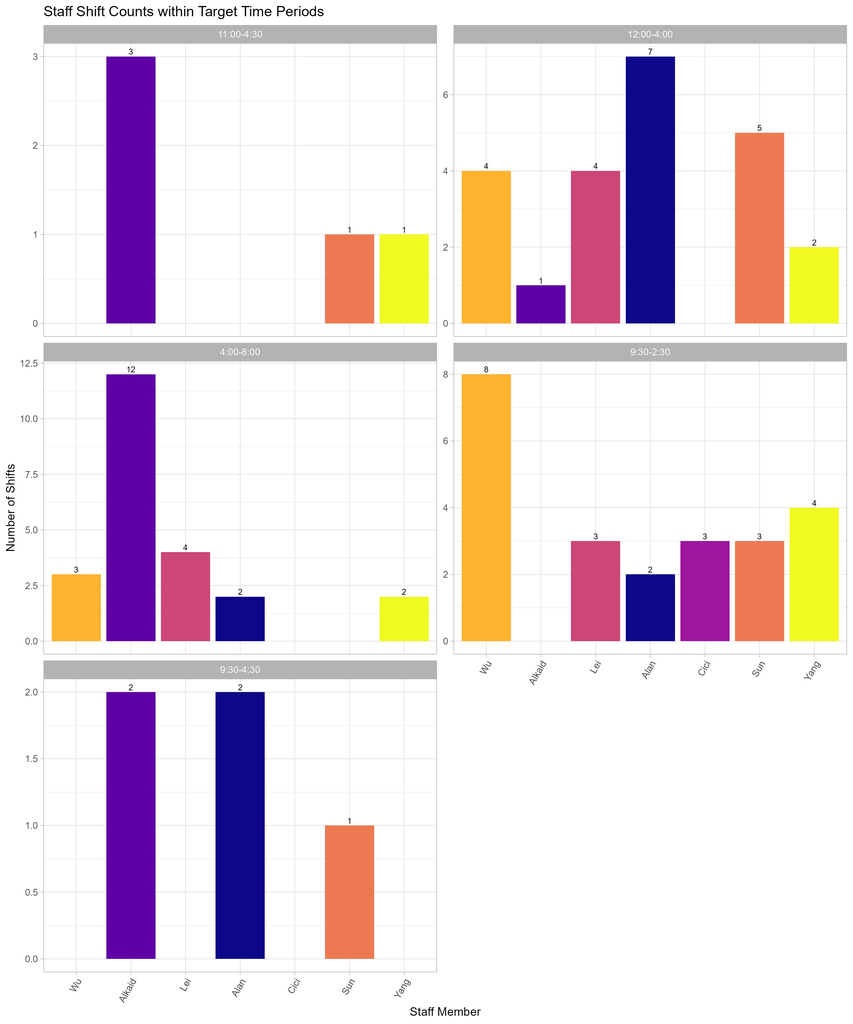

Faceted bar chart showing staff shift counts within target time periods. Each facet represents a shift period, with bars indicating how many times each staff member was observed during that period.

## Finding 4: The Temporal Footprint of Overtime

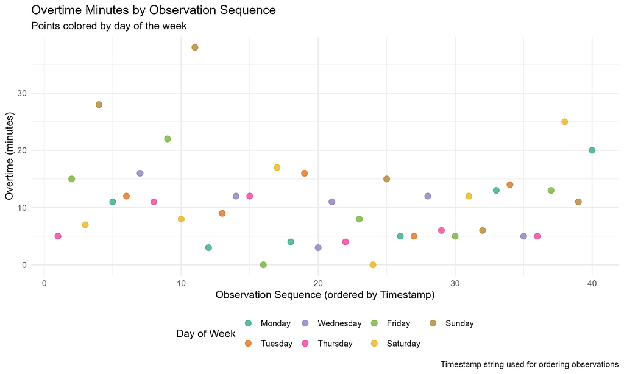

Scatter plot of overtime minutes versus observation sequence, with points colored by the day of the week. Points are generally scattered, with no strong linear upward or downward trend, though weekend days (e.g., yellow and tan points for Saturday/Sunday) often appear at higher overtime levels.

In summary, this scatter plot displays each instance of overtime in chronological order. Although it does not show a clear trend of increasing or decreasing overtime duration over time, it reveals that overtime typically fluctuates around 10 minutes, indicating a certain level of consistency.

## Conclusion and Future Directions

This visual exploration of shift work has illuminated key operational dynamics and overtime patterns. Sunday consistently emerges as the peak day for employee overtime, with Thursday being the lightest, indicating strong weekly cyclical pressures. Notably, a manager’s presence did not correlate with lower median overtime; instead, it was associated with greater variability in overtime durations, suggesting a nuanced role beyond simple overtime reduction, perhaps related to managing more complex or variable tasks.The analysis of staffing in core shift periods revealed distinct patterns of employee coverage, highlighting individuals crucial for specific times (e.g., Alkaid for evenings, Wu for mornings). Finally, overtime occurrences did not show a significant increasing or decreasing trend over the observation period itself, reinforcing that day-of-the-week factors are persistent drivers of overtime.

These findings point to several potential directions for future investigation: a deeper exploration is needed into the high frequency of overtime on Sundays, such as whether it correlates with customer traffic or specific tasks; managers should also be mindful of how their presence may contribute to increased workloads and aim to minimize such occurrences in the future; extending the observation period could help identify seasonal trends. Ultimately, these visualizations offer a data-driven foundation for optimizing scheduling, balancing workloads, and enhancing overall store efficiency and employee well-being.